# Reproducible Research: Peer Assessment 1

Guergana Velitchkova Tzatchkova

## Loading and preprocessing the data

```r
data <- read.csv("activity.csv", header=TRUE)
summary(data)
```

```
##      steps                date          interval
##  Min.   :  0.00   2012-10-01:  288   Min.   :   0.0
##  1st Qu.:  0.00   2012-10-02:  288   1st Qu.: 588.8
##  Median :  0.00   2012-10-03:  288   Median :1177.5
##  Mean   : 37.38   2012-10-04:  288   Mean   :1177.5
##  3rd Qu.: 12.00   2012-10-05:  288   3rd Qu.:1766.2
##  Max.   :806.00   2012-10-06:  288   Max.   :2355.0
##  NA's   :2304     (Other)   :15840
```

## What is mean total number of steps taken per day?

Histogram of total number of steps per day.

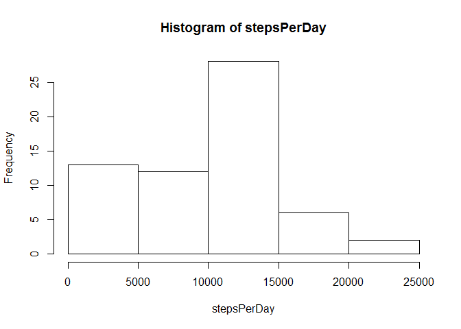

```r
stepsPerDay <- tapply(data$steps, data$date, sum, na.rm=TRUE)
hist(stepsPerDay)
```

Median of steps per day:

```r
median(stepsPerDay)
```

```
## [1] 10395
```

Mean of steps per day:

```r
mean(stepsPerDay)
```

```
## [1] 9354.23
```

## What is the average daily activity pattern?

5-minute interval (x-axis) and the average number of steps taken, averaged across all days (y-axis).

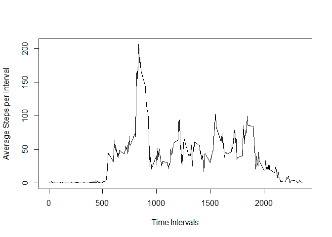

```r
stepsPerInterval <- tapply(data$steps, data$interval, sum, na.rm=TRUE)
meanPerInterval <- tapply(data$steps, data$interval, mean, na.rm=TRUE)

plot(unique(data$interval), meanPerInterval, type="l", xlab="Time Intervals", ylab="Average Steps per Interval")
```

Interval with maximum number of steps: (interval / total steps in that interval)

```r
stepsPerInterval[which.max(stepsPerInterval)]
```

```
##   835
## 10927
```

## Imputing missing values

Total number of missing values in the dataset (i.e. the total number of rows with NAs)

```r
sum(complete.cases(data) == FALSE)
```

```
## [1] 2304
```

Devise a strategy for filling in all of the missing values in the dataset. The strategy does not need to be sophisticated. For example, you could use the mean/median for that day, or the mean for that 5-minute interval, etc.

Replacing NA values with mean for each 5-min interval

```r
myFunction <- function(x, index){
    if( is.na(x) ) { meanPerInterval[index][[1]] } else { x }

}
```

New dataset equal to the original dataset but with the missing data filled in.

```r
noNAdata <- data

noNAdata$steps <- mapply(myFunction, data$steps, seq_along(meanPerInterval))
```

Histogram of total number of steps per day with replaced NAs.

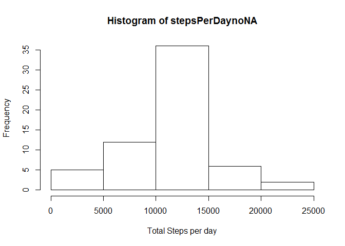

```r
stepsPerDaynoNA <- tapply(noNAdata$steps, noNAdata$date, sum, na.rm=TRUE)
hist(stepsPerDaynoNA, xlab="Total Steps per day")
```

Median of steps per day with estimate values:

```r
median(stepsPerDaynoNA)
```

```
## [1] 10766.19
```

Mean of steps per day with estimate values:

```r
mean(stepsPerDaynoNA)
```

```
## [1] 10766.19
```

## Are there differences in activity patterns between weekdays and weekends?

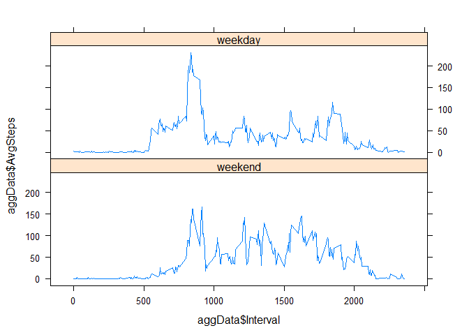

```r
noNAdata$weekday <- weekdays(as.Date(noNAdata$date, format="%Y-%m-%d"))
#create a vector of weekdays
weekdays1 <- c('lunes', 'martes', 'miércoles', 'jueves', 'viernes')
#Use `%in%` and `weekdays` to create a logical vector
#convert to `factor` and specify the `levels/labels`
noNAdata$weekday <-  factor((noNAdata$weekday %in% weekdays1)+1L,
      levels=1:2, labels=c('weekend', 'weekday'))

weekdays <- noNAdata[noNAdata$weekday == "weekday",]
weekends <- noNAdata[noNAdata$weekday == "weekend",]

#plot(weekends$interval, weekends$steps, type="l")
#plot(weekdays$interval, weekdays$steps, type="l")


library(lattice)
#AvgStepsnoNAwDays <- tapply(weekdays$steps, weekdays$interval, mean)
#AvgStepsnoNAwEnds <- tapply(weekends$steps, weekends$interval, mean)

#AvgStepsnoNA <- tapply(noNAdata$steps, noNAdata$interval, noNAdata$weekday , mean)



aggData <- setNames(aggregate(formula = noNAdata$steps~noNAdata$interval+noNAdata$weekday, data = noNAdata,  FUN = mean ), c("Interval", "Weekday",  "AvgSteps"))


xyplot( aggData$AvgSteps ~ aggData$Interval | aggData$Weekday , type="l", layout=c(1,2) )
```